# Prediction Assignment Writeup

Ankit Sharma

July 10, 2019

## Background

Using devices such as Jawbone Up, Nike FuelBand, and Fitbit it is now possible to collect a large amount of data about personal activity relatively inexpensively. These type of devices are part of the quantified self movement - a group of enthusiasts who take measurements about themselves regularly to improve their health, to find patterns in their behavior, or because they are tech geeks. One thing that people regularly do is quantify how much of a particular activity they do, but they rarely quantify how well they do it. In this project, your goal will be to use data from accelerometers on the belt, forearm, arm, and dumbell of 6 participants. They were asked to perform barbell lifts correctly and incorrectly in 5 different ways. More information is available from the website here: http://groupware.les.inf.puc-rio.br/har (see the section on the Weight Lifting Exercise Dataset).

Data The training data for this project are available here:

https://d396qusza40orc.cloudfront.net/predmachlearn/pml-training.csv

The test data are available here:

https://d396qusza40orc.cloudfront.net/predmachlearn/pml-testing.csv

```r
library(caret)
```

```r
library(ggplot2)
library(rpart)
library(randomForest)
```

## Importing Dataset

```r
train=read.csv("pml-training.csv")
test=read.csv("pml-testing.csv")
dim(train)
```

```
## [1] 19622   160
```

```r
table(train$classe)
```

```
##
##    A    B    C    D    E
## 5580 3797 3422 3216 3607
```

## Removing missing data

```r
#Remove column with all missing values
training_set=train[,(colSums(is.na(train))==0)]
testing_set=test[,(colSums(is.na(train))==0)]

nzv<-nearZeroVar(training_set,saveMetrics = TRUE)
training_set= training_set[,nzv$nzv=="FALSE"]
nzv<-nearZeroVar(testing_set,saveMetrics = TRUE)
testing_set= testing_set[,nzv$nzv=="FALSE"]


# Delete variables are irrelevant to our current project: user_name, raw_timestamp_part_1, raw_timestamp_part_,2 cvtd_timestamp, new_window, and  num_window (columns 1 to 7).
training_set   <-training_set[,-c(1:7)]
testing_set <-testing_set[,-c(1:7)]
```

## Cross-validation

we split the cleaned training set into a pure training data set (70%) and a validation data set (30%). We will use the validation data set to conduct cross validation in future steps

```r
intrain=createDataPartition(training_set$classe,p=.70,list = FALSE)

trainingdata=training_set[intrain,]
validationdata=training_set[-intrain,]
```

## Visualization

The variable “classe” contains 5 levels: A, B, C, D and E. A plot of the outcome variable will allow us to see the frequency of each levels in the TrainTrainingSet data set and # compare one another.

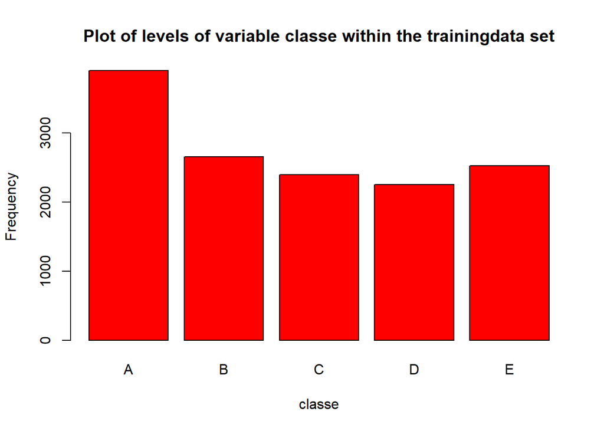

```r
plot(trainingdata$classe,col="red",main="Plot of levels of variable classe within the trainingdata set", xlab="classe", ylab="Frequency")
```

Based on the graph above, we can see that each level frequency is within the same order of magnitude of each other. Level A is the most frequent while level D is the least frequent.

# Prediction model 1: Decision Tree

```r
set.seed(12345)
dtModel <- train(classe ~., method = "rpart", data = trainingdata)
```

```r
Prediction_dt<-predict(dtModel,newdata = validationdata)
# Test results on our subTesting data set:
confusionMatrix(Prediction_dt,validationdata$classe)
```

```
## Confusion Matrix and Statistics
##
##           Reference
## Prediction    A    B    C    D    E
##          A 1509  499  488  415  268
##          B   39  371   46  202  199
##          C   88  136  418  126  142
##          D   35  132   74  221  154
##          E    3    1    0    0  319
##
## Overall Statistics
##
##                Accuracy : 0.4822
##                  95% CI : (0.4694, 0.4951)
##     No Information Rate : 0.2845
##     P-Value [Acc > NIR] : < 2.2e-16
##
##                   Kappa : 0.3223
##
##  Mcnemar's Test P-Value : < 2.2e-16
##
## Statistics by Class:
##
##                      Class: A Class: B Class: C Class: D Class: E
## Sensitivity            0.9014  0.32572  0.40741  0.22925  0.29482
## Specificity            0.6034  0.89760  0.89874  0.91973  0.99917
## Pos Pred Value         0.4747  0.43291  0.45934  0.35877  0.98762
## Neg Pred Value         0.9390  0.84726  0.87779  0.85899  0.86282
## Prevalence             0.2845  0.19354  0.17434  0.16381  0.18386
## Detection Rate         0.2564  0.06304  0.07103  0.03755  0.05421
## Detection Prevalence   0.5402  0.14562  0.15463  0.10467  0.05489
## Balanced Accuracy      0.7524  0.61166  0.65308  0.57449  0.64700
```

# Prediction model 2: Random Forest

```r
set.seed(12345)
rfModel <- randomForest(trainingdata[,-52],trainingdata$classe,ntree = 512)
```

```r
Prediction_rf<-predict(rfModel,newdata = validationdata)
# Test results on our subTesting data set:
confusionMatrix(Prediction_rf,validationdata$classe)
```

```
## Confusion Matrix and Statistics
##
##           Reference
## Prediction    A    B    C    D    E
##          A 1673    4    0    0    0
##          B    0 1131   13    0    0
##          C    0    4 1012    6    2
##          D    0    0    1  957    2
##          E    1    0    0    1 1078
##
## Overall Statistics
##
##                Accuracy : 0.9942
##                  95% CI : (0.9919, 0.996)
##     No Information Rate : 0.2845
##     P-Value [Acc > NIR] : < 2.2e-16
##
##                   Kappa : 0.9927
##
##  Mcnemar's Test P-Value : NA
##
## Statistics by Class:
##
##                      Class: A Class: B Class: C Class: D Class: E
## Sensitivity            0.9994   0.9930   0.9864   0.9927   0.9963
## Specificity            0.9991   0.9973   0.9975   0.9994   0.9996
## Pos Pred Value         0.9976   0.9886   0.9883   0.9969   0.9981
## Neg Pred Value         0.9998   0.9983   0.9971   0.9986   0.9992
## Prevalence             0.2845   0.1935   0.1743   0.1638   0.1839
## Detection Rate         0.2843   0.1922   0.1720   0.1626   0.1832
## Detection Prevalence   0.2850   0.1944   0.1740   0.1631   0.1835
## Balanced Accuracy      0.9992   0.9951   0.9919   0.9961   0.9979
```

```r
# predict outcome levels on the original Testing data set using Random Forest algorithm
predictfinal <- predict(rfModel, testing_set)
predictfinal
```

```
##  1  2  3  4  5  6  7  8  9 10 11 12 13 14 15 16 17 18 19 20
##  B  A  B  A  A  E  D  B  A  A  B  C  B  A  E  E  A  B  B  B
## Levels: A B C D E
```

```r
# Write files for submission
pml_write_files = function(x){
  n = length(x)
  for(i in 1:n){
    filename = paste0("problem_id_",i,".txt")
    write.table(x[i],file=filename,quote=FALSE,row.names=FALSE,col.names=FALSE)
  }
}

pml_write_files(predictfinal)
```